# 人工智慧 進階課程 - Deep Learning- 課程 02 - An introduction to YOLO Algorithm - YOLO 演算法 介紹 - Python Tutorial

### 資料前處理

```python
# 載入圖像

image = Image.open(TEST_IMG_PATH)

print("Before image resize: ", np.array(image, dtype='float32').shape)

# 修改輸入圖像大小來符合模型的要求

resized_iamge = image.resize(tuple(reversed(model_image_size)), Image.BICUBIC)
image_data = np.array(resized_iamge, dtype='float32') # (img_height, img_width, img_channels)

print("After image resize: ", image_data.shape)

# 進行圖像歸一處理 - Normalization

image_data /= 255.

# 增加"批次 Batch "的維度

print("Before expand dims:",image_data.shape) # (img_height, img_width, img_channels)

image_data = np.expand_dims(image_data, 0) # 增加 batch dimension

print("After expand dims:",image_data.shape) # (sample_size, img_height, img_width, img_channels)
```

```
Before image resize:  (576, 768, 3)
After image resize:  (608, 608, 3)
Before expand dims: (608, 608, 3)
After expand dims: (1, 608, 608, 3)
```

```python
# YOLOv2 Model 模型 - 偵測 的結果


out_boxes, out_scores, out_classes = sess.run([boxes, scores, classes],
                                             feed_dict={
                                                 yolo_model.input: image_data,
                                                 input_image_shape: [image.size[1], image.size[0]],
                                                 K.learning_phase(): 0
                                             })

print("out_boxes.shape:", out_boxes.shape, out_boxes.dtype)
print("out_scores.shape:", out_scores.shape, out_scores.dtype)
print("out_classes.shape:", out_classes.shape, out_classes.dtype)
```

```
out_boxes.shape: (3, 4) float32
out_scores.shape: (3,) float32
out_classes.shape: (3,) int64
```

```python
# 列印 找到個 - Bounding Boxes

print('Found {} boxes for {}'.format(len(out_boxes),TEST_IMG))

# 列印每個找到 - 物體類別、信心分數與 - 邊框 - 左上角 與 右下角座標

for i, c in reversed(list(enumerate(out_classes))):
    predicted_class = class_names[c]
    box = out_boxes[i]
    score = out_scores[i]

    top, left, bottom, right = box
    top = max(0, np.floor(top + 0.5).astype('int32'))                   # 避免左上角座標超出原始圖像的左上角(0,0)
    left = max(0, np.floor(left + 0.5).astype('int32'))                 # 避免左上角座標超出原始圖像的左上角(0,0)
    bottom = min(image.size[1], np.floor(bottom + 0.5).astype('int32')) # 避免右下角座標超出原始圖像的右下角(608,608)
    right = min(image.size[0], np.floor(right + 0.5).astype('int32'))   # 避免右下角座標超出原始圖像的右下角(608,608)

    label = '{} {:.2f} [({}, {}),({}, {})]'.format(predicted_class, score, top, left, bottom, right)
    print(label)
```

```
Found 3 boxes for dog.jpg
dog 0.78 [(214, 137),(540, 323)]
truck 0.80 [(82, 462),(168, 694)]
bicycle 0.84 [(112, 81),(469, 554)]
```

''' >>圖像 偵測 - 的結果 >> 圖像上 - 繪製 物體類別、信心分數 與 邊框 '''

```
dog 0.78 (137, 214) (323, 540)
truck 0.80 (462, 82) (694, 168)
bicycle 0.84 (81, 112) (554, 469)
```

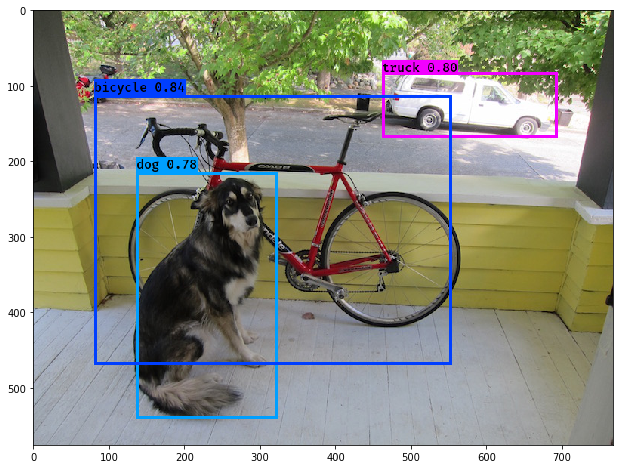

```python
#  設定字型 - font/FiraMono-Medium.otf  - Option - font/SIL Open Font License.txt

font = ImageFont.truetype(font='font/FiraMono-Medium.otf',
                         size=np.floor(3e-2 * image.size[1]+0.5).astype('int32'))

# 設定邊框 - 厚度

thickness = (image.size[0]+image.size[1]) // 300

# 迭代 - 每個找到的 - 物體類別
for i, c in reversed(list(enumerate(out_classes))):
    predicted_class = class_names[c]
    box = out_boxes[i]
    score = out_scores[i]

    label = '{} {:.2f}'.format(predicted_class, score)

    draw = ImageDraw.Draw(image) # 使用 Draw  - 圖像上 - 畫圖

    label_size = draw.textsize(label, font) #  物體類別 -  信心分數 - 以文字 表現

    #  - 邊框 -  座標

    top, left, bottom, right = box
    top = max(0, np.floor(top + 0.5).astype('int32'))
    left = max(0, np.floor(left + 0.5).astype('int32'))
    bottom = min(image.size[1], np.floor(bottom + 0.5).astype('int32'))
    right = min(image.size[0], np.floor(right + 0.5).astype('int32'))

    # 列印 - 圖像類別, 邊界框 的 - 左上角 - 右下角 --- 座標

    print(label, (left, top), (right, bottom))

    if top - label_size[1] >= 0:
        text_origin = np.array([left, top - label_size[1]])
    else:
        text_origin = np.array([left, top + 1])


    for i in range(thickness):
        # 畫  - 邊框
        draw.rectangle(
            [left + i, top + i, right - i, bottom - i],
            outline=colors[c])

    # 畫一個-  四方型 -  做 - 文字標籤的背景
    draw.rectangle(
        [tuple(text_origin), tuple(text_origin + label_size)],
        fill=colors[c])

    #  文字標籤的資訊 - 到圖像上
    draw.text(text_origin, label, fill=(0, 0, 0), font=font)

    del draw # 移除 - draw 物件

# 將- 最後的圖像 - 畫出來

plt.figure(figsize=(15,8)) # 設定 - 列印圖像大小
plt.imshow(image) # 展示

# 儲存處理過的圖像  - Option
# image.save(os.path.join(OUTPUT_PATH, image_file), quality=90)
```

```python
# 關閉 Close it U p  - Tensorflow  - Session

sess.close()
```